# Danish Kings for week 10

Emilie Balslev Pedersen

2025-14-05

## Set up tidyverse

```r
library(tidyverse)
```

## Load the kings

1. Look at the dataset that are you loading and check what its columns are separated by? List what is the separator: ## the seperator is semikolon = ;
2. Create a `kings` object in R with the different functions below and inspect the different outputs.
- `read.csv()`
- `read_csv()`
- `read.csv2()`
- `read_csv2()`

```r
# FILL IN THE CODE BELOW and review the outputs
kings1 <- read.csv("data/danskekonger.csv")
head(kings1)
```

```
##   key_ID.Foedselsaar.konge.indsaet.afslut.Doed
## 1               1;NA;Gorm_den_gamle;936;958;NA
## 2             2;911;Harald_blåtand;958;987;987
## 3            3;963;Svend_Tveskæg;987;1014;1014
## 4               4;994;Harald_II;1014;1018;1018
## 5          5;994;Knud_den_Store;1018;1035;1035
## 6              6;1018;Hardeknud;1035;1042;1042
```

```r
mine_konger <- read_csv2("data/danskekonger.csv",na="NA")
head(mine_konger)
```

```
## # A tibble: 6 × 6
##   key_ID Foedselsaar konge          indsaet afslut  Doed
##    <dbl>       <dbl> <chr>            <dbl>  <dbl> <dbl>
## 1      1          NA Gorm_den_gamle     936    958    NA
## 2      2         911 Harald_blåtand     958    987   987
## 3      3         963 Svend_Tveskæg      987   1014  1014
## 4      4         994 Harald_II         1014   1018  1018
## 5      5         994 Knud_den_Store    1018   1035  1035
## 6      6        1018 Hardeknud         1035   1042  1042
```

```r
kings3 <- read.csv2("data/danskekonger.csv")
head(kings3)
```

```
##   key_ID Foedselsaar          konge indsaet afslut Doed
## 1      1          NA Gorm_den_gamle     936    958   NA
## 2      2         911 Harald_blåtand     958    987  987
## 3      3         963  Svend_Tveskæg     987   1014 1014
## 4      4         994      Harald_II    1014   1018 1018
## 5      5         994 Knud_den_Store    1018   1035 1035
## 6      6        1018      Hardeknud    1035   1042 1042
```

```r
kings4 <- read_csv( "data/danskekonger.csv")
head(kings4)
```

```
## # A tibble: 6 × 1
##   `key_ID;Foedselsaar;konge;indsaet;afslut;Doed`
##   <chr>
## 1 1;NA;Gorm_den_gamle;936;958;NA
## 2 2;911;Harald_blåtand;958;987;987
## 3 3;963;Svend_Tveskæg;987;1014;1014
## 4 4;994;Harald_II;1014;1018;1018
## 5 5;994;Knud_den_Store;1018;1035;1035
## 6 6;1018;Hardeknud;1035;1042;1042
```

Answer: 1. Which of these functions is a `tidyverse` function? Read data with it below into a `kings` object ## read_csv and read_csv2 are tidyverse functions. read.csv and read.csv2 are a part of the basis R functions. Since this data set is semikolon seperated it works best with read_csv2 and read.csv2.

2. What is the result of running `class()` on the `kings` object created with a tidyverse function. # This is the result: [1] “spec_tbl_df” “tbl_df” “tbl” “data.frame”. ## This means that the object is a both a tibble that works with the tidyverse functions and a data frame that works with the regular R functions. Ergo can both features from tidyverse and R be used for working with the object.
3. How many columns does the object have when created with these different functions? # Both using the data.frame and tbl_df function the object is created with 6 columns ## To make sure that is correct we use the glimpse function which shows the object has 6 columns. Same goes when using the ncol function which counts the columns (= 6)
4. Show the dataset so that we can see how R interprets each column

```r
# Classifying the dataset

kings <- mine_konger

class(kings)
```

```
## [1] "spec_tbl_df" "tbl_df"      "tbl"         "data.frame"
```

```r
glimpse(kings)
```

```
## Rows: 57
## Columns: 6
## $ key_ID      <dbl> 1, 2, 3, 4, 5, 6, 7, 8, 9, 10, 11, 12, 13, 14, 15, 16, 17,…
## $ Foedselsaar <dbl> NA, 911, 963, 994, 994, 1018, 1024, 1019, NA, 1043, 1050, …
## $ konge       <chr> "Gorm_den_gamle", "Harald_blåtand", "Svend_Tveskæg", "Hara…
## $ indsaet     <dbl> 936, 958, 987, 1014, 1018, 1035, 1042, 1047, 1074, 1080, 1…
## $ afslut      <dbl> 958, 987, 1014, 1018, 1035, 1042, 1047, 1074, 1080, 1086, …
## $ Doed        <dbl> NA, 987, 1014, 1018, 1035, 1042, 1047, NA, 1080, 1086, 109…
```

```r
ncol(kings)
```

```
## [1] 6
```

```r
data.frame(kings)
```

```
##    key_ID Foedselsaar                 konge indsaet afslut Doed
## 1       1          NA        Gorm_den_gamle     936    958   NA
## 2       2         911        Harald_blåtand     958    987  987
## 3       3         963         Svend_Tveskæg     987   1014 1014
## 4       4         994             Harald_II    1014   1018 1018
## 5       5         994        Knud_den_Store    1018   1035 1035
## 6       6        1018             Hardeknud    1035   1042 1042
## 7       7        1024       Magnus_den_gode    1042   1047 1047
## 8       8        1019    Svend_II_Estridsen    1047   1074   NA
## 9       9          NA         Harald_II_Hen    1074   1080 1080
## 10     10        1043   Knud_II_den_hellige    1080   1086 1086
## 11     11        1050         Oluf_I_Hunger    1086   1095 1095
## 12     12        1056         Erik_I_Ejegod    1095   1103 1103
## 13     13        1065                 Niels    1104   1134 1134
## 14     14        1090            Erik_Emune    1134   1137 1137
```

[output cut: 43 more lines]

```r
as_tibble(kings)
```

```
## # A tibble: 57 × 6
##    key_ID Foedselsaar konge               indsaet afslut  Doed
##     <dbl>       <dbl> <chr>                 <dbl>  <dbl> <dbl>
##  1      1          NA Gorm_den_gamle          936    958    NA
##  2      2         911 Harald_blåtand          958    987   987
##  3      3         963 Svend_Tveskæg           987   1014  1014
##  4      4         994 Harald_II              1014   1018  1018
##  5      5         994 Knud_den_Store         1018   1035  1035
##  6      6        1018 Hardeknud              1035   1042  1042
##  7      7        1024 Magnus_den_gode        1042   1047  1047
##  8      8        1019 Svend_II_Estridsen     1047   1074    NA
##  9      9          NA Harald_II_Hen          1074   1080  1080
## 10     10        1043 Knud_II_den_hellige    1080   1086  1086
## # ℹ 47 more rows
```

## Calculate the duration of reign for all the kings in your table

```r
# Getting R to ignore NA
library(tidyverse)
na.omit(kings)
```

```
## # A tibble: 47 × 6
##    key_ID Foedselsaar konge               indsaet afslut  Doed
##     <dbl>       <dbl> <chr>                 <dbl>  <dbl> <dbl>
##  1      2         911 Harald_blåtand          958    987   987
##  2      3         963 Svend_Tveskæg           987   1014  1014
##  3      4         994 Harald_II              1014   1018  1018
##  4      5         994 Knud_den_Store         1018   1035  1035
##  5      6        1018 Hardeknud              1035   1042  1042
##  6      7        1024 Magnus_den_gode        1042   1047  1047
##  7     10        1043 Knud_II_den_hellige    1080   1086  1086
##  8     11        1050 Oluf_I_Hunger          1086   1095  1095
##  9     12        1056 Erik_I_Ejegod          1095   1103  1103
## 10     13        1065 Niels                  1104   1134  1134
## # ℹ 37 more rows
```

```r
glimpse(kings)
```

```
## Rows: 57
## Columns: 6
## $ key_ID      <dbl> 1, 2, 3, 4, 5, 6, 7, 8, 9, 10, 11, 12, 13, 14, 15, 16, 17,…
## $ Foedselsaar <dbl> NA, 911, 963, 994, 994, 1018, 1024, 1019, NA, 1043, 1050, …
## $ konge       <chr> "Gorm_den_gamle", "Harald_blåtand", "Svend_Tveskæg", "Hara…
## $ indsaet     <dbl> 936, 958, 987, 1014, 1018, 1035, 1042, 1047, 1074, 1080, 1…
## $ afslut      <dbl> 958, 987, 1014, 1018, 1035, 1042, 1047, 1074, 1080, 1086, …
## $ Doed        <dbl> NA, 987, 1014, 1018, 1035, 1042, 1047, NA, 1080, 1086, 109…
```

```r
# Mutate() to create new columns and calculating duration
kings <- kings %>%
  mutate(duration = afslut-indsaet)
glimpse(kings)
```

```
## Rows: 57
## Columns: 7
## $ key_ID      <dbl> 1, 2, 3, 4, 5, 6, 7, 8, 9, 10, 11, 12, 13, 14, 15, 16, 17,…
## $ Foedselsaar <dbl> NA, 911, 963, 994, 994, 1018, 1024, 1019, NA, 1043, 1050, …
## $ konge       <chr> "Gorm_den_gamle", "Harald_blåtand", "Svend_Tveskæg", "Hara…
## $ indsaet     <dbl> 936, 958, 987, 1014, 1018, 1035, 1042, 1047, 1074, 1080, 1…
## $ afslut      <dbl> 958, 987, 1014, 1018, 1035, 1042, 1047, 1074, 1080, 1086, …
## $ Doed        <dbl> NA, 987, 1014, 1018, 1035, 1042, 1047, NA, 1080, 1086, 109…
## $ duration    <dbl> 22, 29, 27, 4, 17, 7, 5, 27, 6, 6, 9, 8, 30, 3, 9, 11, 25,…
```

## Calculate the average duration of reign for all rulers

# Answer: The average duration of reign is 19.7272 years

```r
library(tidyverse)

# Find the median
mean(kings$duration,na.rm = T)
```

```
## [1] 19.72727
```

## How many and which kings enjoyed a longer-than-average duration of reign?

```r
# Monarchs ruling longer than average

kings %>%
  filter(kings$duration>19.72727) %>%
  count(konge,duration)
```

```
## # A tibble: 28 × 3
##    konge           duration     n
##    <chr>              <dbl> <int>
##  1 Christian_I           33     1
##  2 Christian_III         25     1
##  3 Christian_IV          60     1
##  4 Christian_IX          43     1
##  5 Christian_V           29     1
##  6 Christian_VII         42     1
##  7 Christian_X           35     1
##  8 Erik_Klipping         27     1
##  9 Erik_Menved           33     1
## 10 Erik_af_Pommern       27     1
## # ℹ 18 more rows
```

## How many days did the three longest-ruling monarchs rule?

```r
# Finding the reign calculated by number of days for the 3 longest-ruling monarchs

kings %>%
  filter(kings$duration>19.72727) %>%
  mutate(duration_days=duration*365.25) %>%
  arrange(desc(duration_days)) %>%
  slice(1:3)
```

```
## # A tibble: 3 × 8
##   key_ID Foedselsaar konge        indsaet afslut  Doed duration duration_days
##    <dbl>       <dbl> <chr>          <dbl>  <dbl> <dbl>    <dbl>         <dbl>
## 1     41        1577 Christian_IV    1588   1648  1648       60        21915
## 2     55        1940 Margrethe_II    1972   2024    NA       52        18993
## 3     51        1818 Christian_IX    1863   1906  1906       43        15706.
```

## Challenge: Plot the kings’ duration of reign through time

What is the long-term trend in the duration of reign among Danish monarchs? How does it relate to the historical violence trends ? ## It is shown in the graph that the duration of reign among Danish monarchs is getting longer throughout time. This could be credited to a historical general decline in political violence and also a better understanding of hygiene and curing deceases.

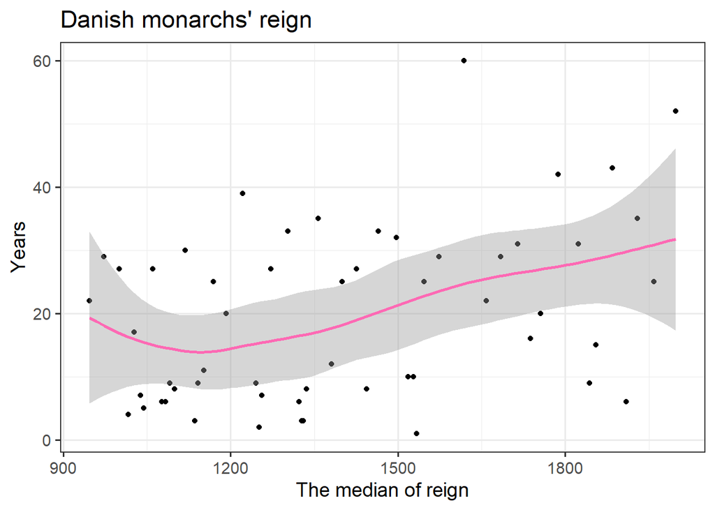

```r
# Graph illustrating the average rule of Danish monarchs

kings %>%
  mutate(midyear = indsaet + duration / 2) %>%
  mutate(navn_titel = paste(konge)) %>%
  filter(!is.na(midyear), !is.na(duration)) %>%
  ggplot(aes(x = midyear, y = duration)) +
  geom_point() +
  geom_smooth(color = "hotpink") +
  labs(
    title = "Danish monarchs' reign",
    x = "The median of reign",
    y = "Years"
  ) +
  theme_bw(base_size = 14)
```